# Case Study: Bellabeat

Adjei Anthony Junior

### About comapany

Bellabeat is a technology company founded in 2013 that aims to create innovative health and wellness products specifically designed for women. The company is committed to empowering women with tools and knowledge to help them achieve their wellness goals and improve their overall quality of life. Bellabeat’s products, including smart jewelry and fitness trackers, are designed to track various aspects of women’s health, such as activity levels, sleep quality, stress, and reproductive health. The company’s products combine technology and aesthetics, with a focus on creating devices that are both functional and stylish.

### Buiness task

Analyze smart device usage data in order to gain insight into how people are already using their smart devices. Then, give recommendations for how these trends can inform Bellabeat marketing strategy

## source of dataset

The data set generated by respondents to a distributed survey via Amazon Mechanical Turk, public data that explores smart device users’ daily habits FitBit Fitness Tracker Data (CC0: Public Domain, data set made available through Mobius): This Kaggle data set contains personal fitness tracker from thirty fitbit users. Thirty eligible Fitbit users consented to the submission of personal tracker data, including minute-level output for physical activity, heart rate, and sleep monitoring.

### QUESTION ASK

1.What are some trends in smart device usage? 2 . How could these trends apply to Bella beat customers? 3. How could these trends help influence Bella beat marketing strategy?

```r
library(tidyverse)
```

```r
library(corrplot)
knitr::opts_chunk$set(echo = FALSE)
```

### cleaning and checking Data

```
##           Id ActivityDate TotalSteps TotalDistance TrackerDistance
## 1 1503960366    4/12/2016      13162          8.50            8.50
## 2 1503960366    4/13/2016      10735          6.97            6.97
## 3 1503960366    4/14/2016      10460          6.74            6.74
## 4 1503960366    4/15/2016       9762          6.28            6.28
## 5 1503960366    4/16/2016      12669          8.16            8.16
## 6 1503960366    4/17/2016       9705          6.48            6.48
##   LoggedActivitiesDistance VeryActiveDistance ModeratelyActiveDistance
## 1                        0               1.88                     0.55
## 2                        0               1.57                     0.69
## 3                        0               2.44                     0.40
## 4                        0               2.14                     1.26
## 5                        0               2.71                     0.41
## 6                        0               3.19                     0.78
##   LightActiveDistance SedentaryActiveDistance VeryActiveMinutes
## 1                6.06                       0                25
## 2                4.71                       0                21
## 3                3.91                       0                30
## 4                2.83                       0                29
## 5                5.04                       0                36
## 6                2.51                       0                38
##   FairlyActiveMinutes LightlyActiveMinutes SedentaryMinutes Calories
## 1                  13                  328              728     1985
## 2                  19                  217              776     1797
## 3                  11                  181             1218     1776
## 4                  34                  209              726     1745
## 5                  10                  221              773     1863
## 6                  20                  164              539     1728
```

```
## [1] FALSE
```

```
## [1] 940  15
```

```
## 'data.frame':    940 obs. of  15 variables:
##  $ Id                      : num  1.5e+09 1.5e+09 1.5e+09 1.5e+09 1.5e+09 ...
##  $ ActivityDate            : chr  "4/12/2016" "4/13/2016" "4/14/2016" "4/15/2016" ...
##  $ TotalSteps              : int  13162 10735 10460 9762 12669 9705 13019 15506 10544 9819 ...
##  $ TotalDistance           : num  8.5 6.97 6.74 6.28 8.16 ...
##  $ TrackerDistance         : num  8.5 6.97 6.74 6.28 8.16 ...
##  $ LoggedActivitiesDistance: num  0 0 0 0 0 0 0 0 0 0 ...
##  $ VeryActiveDistance      : num  1.88 1.57 2.44 2.14 2.71 ...
##  $ ModeratelyActiveDistance: num  0.55 0.69 0.4 1.26 0.41 ...
##  $ LightActiveDistance     : num  6.06 4.71 3.91 2.83 5.04 ...
##  $ SedentaryActiveDistance : num  0 0 0 0 0 0 0 0 0 0 ...
##  $ VeryActiveMinutes       : int  25 21 30 29 36 38 42 50 28 19 ...
##  $ FairlyActiveMinutes     : int  13 19 11 34 10 20 16 31 12 8 ...
##  $ LightlyActiveMinutes    : int  328 217 181 209 221 164 233 264 205 211 ...
##  $ SedentaryMinutes        : int  728 776 1218 726 773 539 1149 775 818 838 ...
##  $ Calories                : int  1985 1797 1776 1745 1863 1728 1921 2035 1786 1775 ...
```

```
##           Id              SleepDay TotalSleepRecords TotalMinutesAsleep
## 1 1503960366 4/12/2016 12:00:00 AM                 1                327
## 2 1503960366 4/13/2016 12:00:00 AM                 2                384
## 3 1503960366 4/15/2016 12:00:00 AM                 1                412
## 4 1503960366 4/16/2016 12:00:00 AM                 2                340
## 5 1503960366 4/17/2016 12:00:00 AM                 1                700
## 6 1503960366 4/19/2016 12:00:00 AM                 1                304
##   TotalTimeInBed
## 1            346
## 2            407
## 3            442
## 4            367
## 5            712
## 6            320
```

```
## [1] FALSE
```

```
## [1] 413   5
```

```
## 'data.frame':    413 obs. of  5 variables:
##  $ Id                : num  1.5e+09 1.5e+09 1.5e+09 1.5e+09 1.5e+09 ...
##  $ SleepDay          : chr  "4/12/2016 12:00:00 AM" "4/13/2016 12:00:00 AM" "4/15/2016 12:00:00 AM" "4/16/2016 12:00:00 AM" ...
##  $ TotalSleepRecords : int  1 2 1 2 1 1 1 1 1 1 ...
##  $ TotalMinutesAsleep: int  327 384 412 340 700 304 360 325 361 430 ...
##  $ TotalTimeInBed    : int  346 407 442 367 712 320 377 364 384 449 ...
```

### Data Analysis

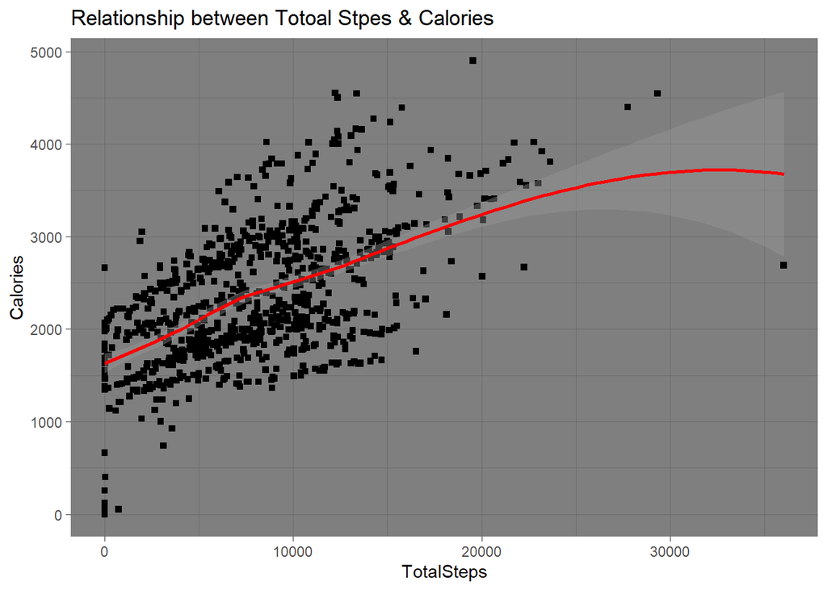

The total number of steps taken by users and calories burnt have been found to positively correlate. This implies that the calories burnt rise along with the number of steps taken.

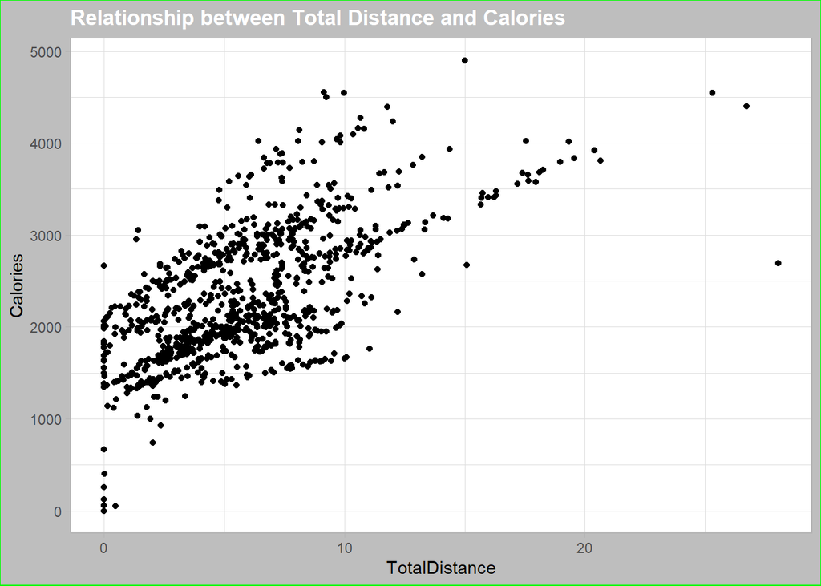

Total distance traveled and calories burned have a tenuous positive association. This implies that when a person moves farther, they start to burn calories, but not as much, depending on the individual

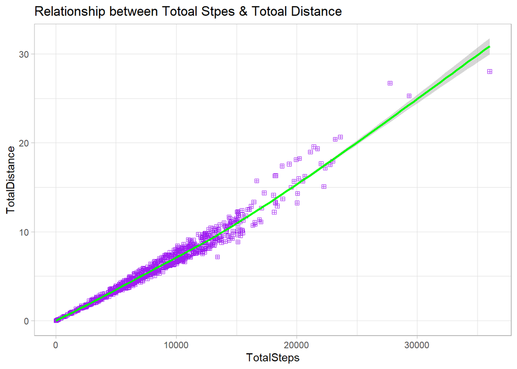

It is true that a person must take more steps in order to get farther on foot.

[figure not shown]

The number of steps or walks taken decreases when a person spends more time in bed, however not at a particularly rapid rate because other factors might be at play.

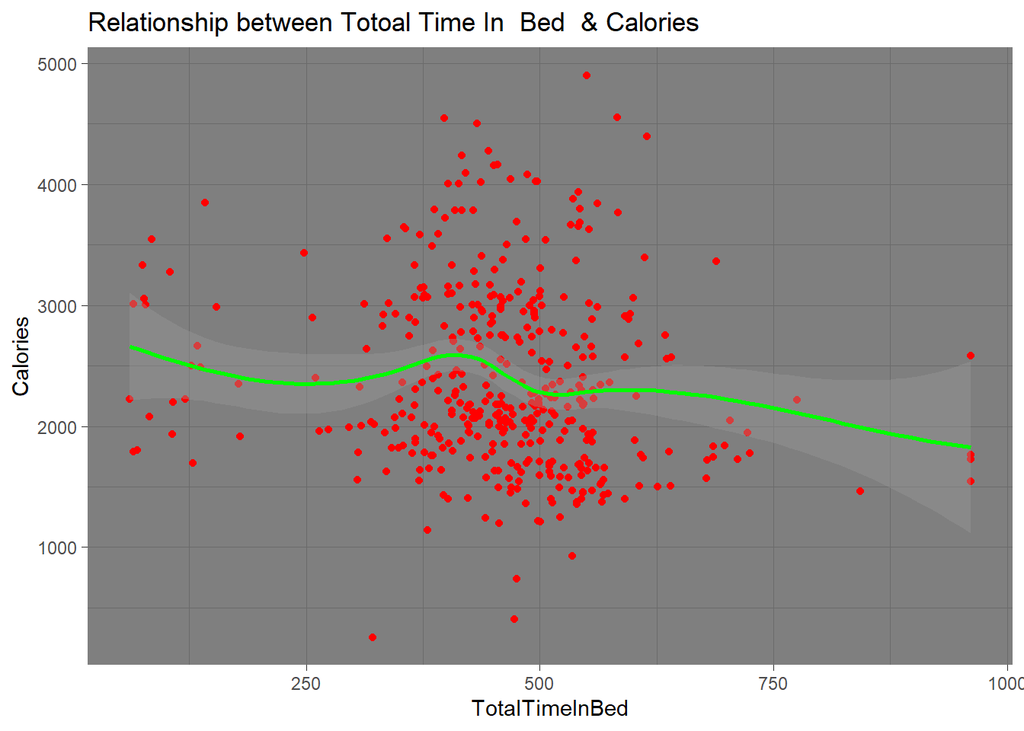

The quantity of calories consumed and the overall length of time spent in bed have a modest negative association. This may not always be the case since other criteria, such as the sort of employment and the amount of exercise involved, will also be taken into consideration.

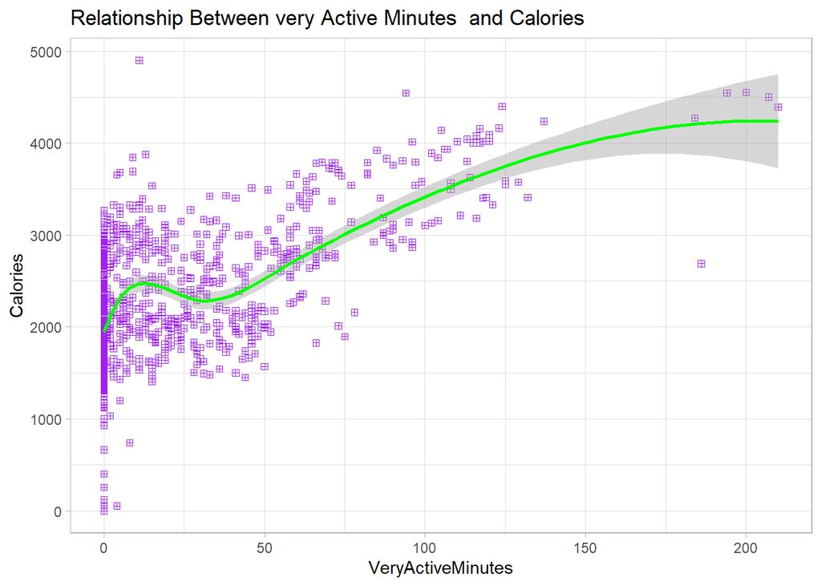

Moreover, highly Active Mints and the number of calories in a serving have a weakly positive association. This may not always be the case since other criteria, such as the sort of employment and exercise involved, will also be taken into consideration.

```
##                   VeryActiveMinutes   Calories TotalDistance TotalSteps
## VeryActiveMinutes         1.0000000  0.4608077     0.6997403  0.6903232
## Calories                  0.4608077  1.0000000     0.4499292  0.3395795
## TotalDistance             0.6997403  0.4499292     1.0000000  0.9805077
## TotalSteps                0.6903232  0.3395795     0.9805077  1.0000000
## TotalTimeInBed           -0.2381849 -0.1753540    -0.1955572 -0.1929921
##                   TotalTimeInBed
## VeryActiveMinutes     -0.2381849
## Calories              -0.1753540
## TotalDistance         -0.1955572
## TotalSteps            -0.1929921
## TotalTimeInBed         1.0000000
```

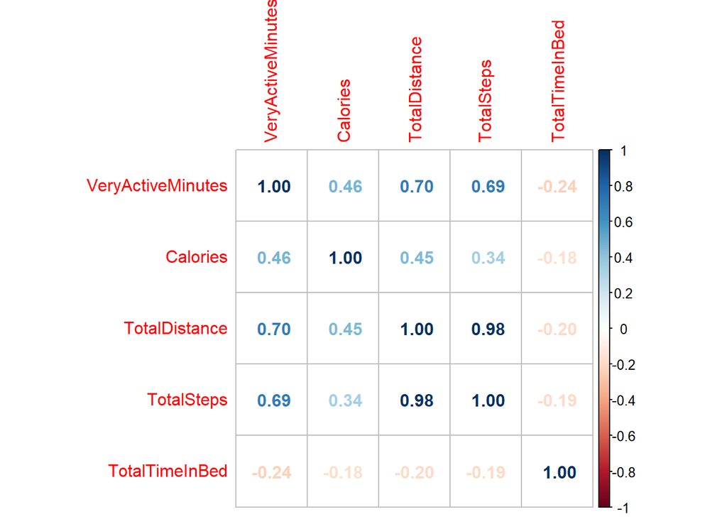

Above diagram show the summary of the correlation vaules between the selected variables

### conclusion

#### Conclusion and Recommendation

1.What are some trends in smart device usage?

The results from the data shows that there is a positive relationship in High very active minutes of users, total distance covered, and total steps to calories burnt. Therefore, a user who is very active for more minutes will have increase in calories burnt and also any user covering more distance and taken more steps daily will also have an increase in calories burnt recorded by the device. Daily habit of spending more time in bed result indicate that a user will have less very active minutes, and also may not or will burn less calories during the day, and will also have fewer total steps count by the device. More count on total steps helps in covering more distance.

2. How could these trends apply to Bellabeat customers?

Bellabeat can ensure their customers on having more very active minutes or having more total steps count by their product will result in burning more calories, and for customers who want to burn more calories can try having more walk and high very active minutes count by their device.

3 how these trends can inform Bellabeat marketing strategy ?

Bellabeat company can set a notification system on their device to inform user on if they have lose or gain more calories use the trends and also predict on their daily toatal step, very active minute and total distance using their total time spend in bed. This may let more people hsve intrest in their product.